[figure not shown]

# Business information systems: concept, components, functions and life cycle

**Business Information Systems**  
**Assoc. prof. Darko Etinger, Ph.D.**

# System approach and system concept

The term **system** means any **ordered set consisting of at least two elements** that **interact** (interact) to achieve some, simple or complex, **function of the whole** . The number of elements that make up a system is not limited, but it must be a finite number. The system is part of the universe, that is, its own **environment** in which it operates and with which it maintains certain **connections** .

With regard to **orientation** (direction), there are:

- inbound links (symbolically marked as U),
- output connections (symbolically: I).

Due to the nature of the relationship, there are:

- material ties,
- energy connections,
- information links.

Within the system, a certain process of transformation (transformations, symbolically expressed as **T** ) of inputs into system outputs takes place, which can be formulated by the expression:

*I* = *U* * *T*

Thus, the system output (system function) is realized by the action of the transformation process (operator) on the system input.

For the schematic representation of the relationship between the observed system and its environment, and the eventual research of these relationships, the Black Box Method is most often **used .**

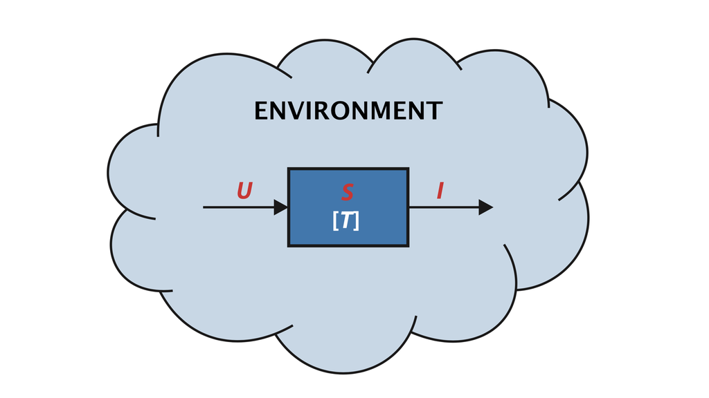

It is important to note the **legality of the hierarchy and relativity of the system definition** . According to this law, each system is considered a subsystem of a higher order system, while at the same time each system can be broken down into lower order subsystems. **The upper limit** of such a relative understanding of the system is the **infinite system, and the lower limit is the indivisible element** . The definition of a phenomenon as a system or subsystem of a higher order system depends on the attitude of the observer towards that phenomenon. The phenomenon of which the observer himself is an integral part, he will define as a system, and the phenomena that are logically subordinate to him as subsystems.

The system is bounded by environmental boundaries, which can be **physical** or **logical** . Before any research into the system, its properties and functions, its boundaries to the environment must be precisely determined.

Depending on the nature of the elements of which they are composed, systems can be **concrete, abstract or hybrid** (mixed), and given the behavior in time **static** (time-invariant) and **dynamic** (time-changeable).

# The concept of business information system

Each system exchanges information with its environment, in addition to matter and energy, ie maintains some **information connections** . Within the system, input information is processed, ie transformed or transformed into output information. In the elementary definition, therefore, the **term information system means that part of the real (real, concrete) system that serves to transform input into output information.**

> DEFINITION: An information system is an organized set of elements, ie components that interact to perform the functions of collecting, processing, storing and disseminating (publishing) information.

In business systems, information systems support and serve business processes and operations, business decision making and the development and implementation of competitive business strategies. In this sense, we can talk about **business information systems** (EIS).

## Business information system components

It consists of the following components:

1. material and technical components,
2. intangible components,
3. human components,
4. network components,
5. organizational components.

## Business information system functions

Modern business information systems should perform, generally speaking, two basic functions:

1. preparation of information base for making business decisions,
2. documenting, ie permanent storage of previously generated information.

## Preparation of information base for business decisions

### Key properties of information

The essential properties (attributes) of each information are:

1. quality (quality),
2. quantity,
3. value in time.

**Quality** : the ability to meet the information needs of users, or to achieve conditions in which the user can make the appropriate decision,

**Quantity (quantity)** : top management needs relatively little synthetic information when making decisions, which will allow it to gain a good general insight into the problem. Executive management requires a slightly larger amount of partially aggregated (summarized) information, and operational management requires a lot of analytical information related to the details of running business processes.

**Value over time** : - the area of forecasting, when relevant information is obtained even before a decision needs to be made. Its value is then greatest and it decreases nonlinearly. - the area of real time in which information is obtained (or created) just when a decision needs to be made. - the area of obsolescence, which occurs when the information is received too late, when the decision is no longer needed or is not relevant for the further course of events (processes).

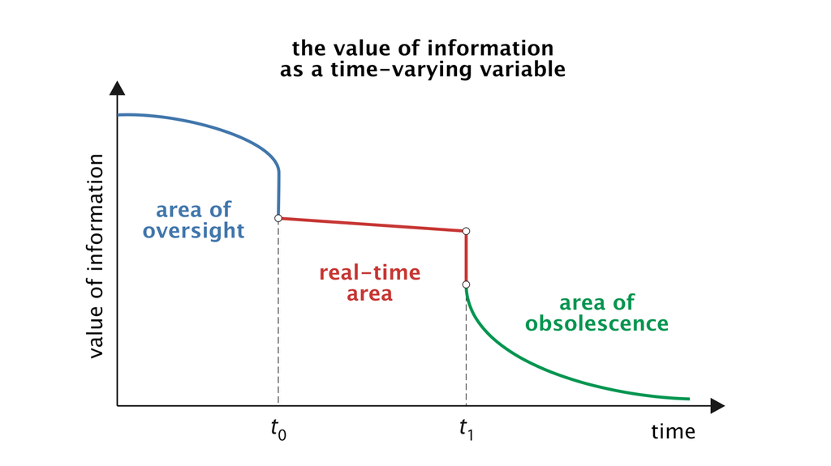

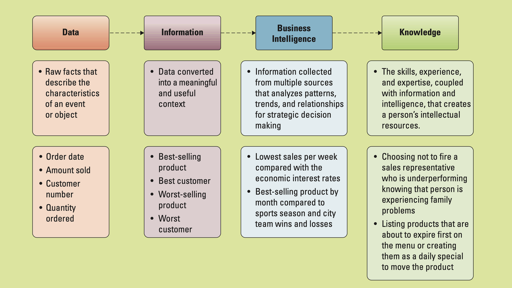

## Preparation of information for business decision making

- collection of business relevant data,
- processing of this data, ie their conversion into business-relevant information,
- dissemination of information to users.

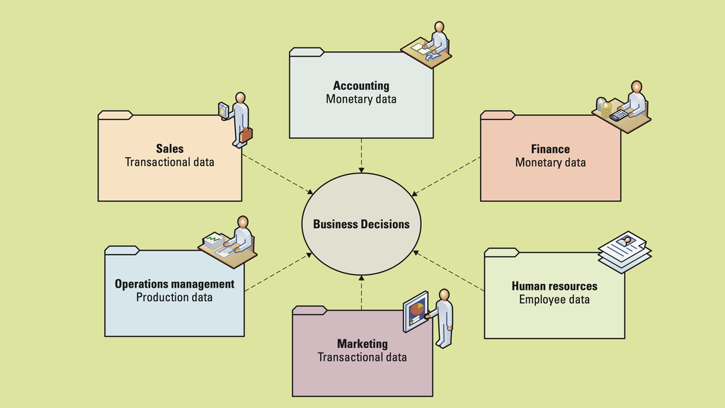

# Business information system life cycle

Business information system management today is based on the general concept **of the** System Life Cycle.

The essence of the concept of the life cycle of a business information system is the understanding according to which each such system at some point in time is created, then developed according to certain laws to disappear after a certain time, or be replaced by a new system.

The concept of the system life cycle consists of four basic development phases:

1. initialization phase,
2. expansion phase (growth),
3. consolidation phase,
4. phase of maturity of the system

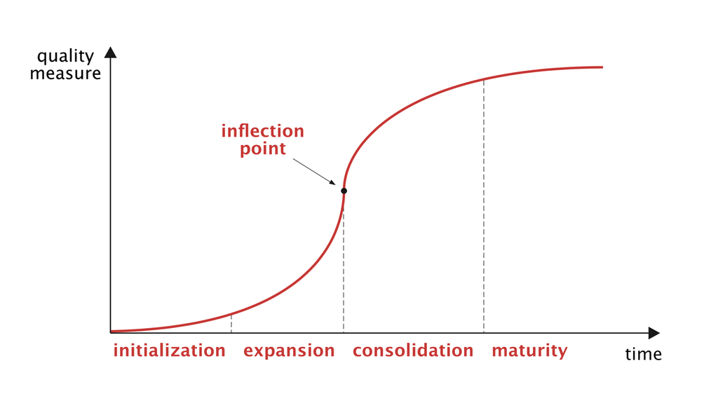